# WQP Lake Linking Example

Luke Winslow

2018-04-12

## Linking Water Quality Portal

This is an example of using `hydrolinks` to link a large, unlinked aquatic dataset to the U.S. Geological Survey’s National Hydrography Network. The unlinked aquatic dataset is from the Water Quality Portal (WQP). In this example, I will link a lakes, but you could also link streams.

First, load packages and grab lake data. I’m limiting the data to be from the state of Wisconsin initially. This just speeds up generation of the Vignette. The entire US dataset takes a bit longer than I’d like to wait to link and visualize.

```r
library(dataRetrieval)
library(hydrolinks)
library(USAboundaries)
#library(ggplot2)
#library(gridExtra)
library(sf)
hydrolinks::cache_set_dir(temppath = TRUE)

lsites = whatWQPsites(siteType ="Lake, Reservoir, Impoundment", statecode='US:55')
```

At the point of this Vignette generation, there were 19356 unique sites returned by this query.

Now, lets link all these sites to the NHDH. After the initial point-in-polygon linking, I will take the remainder and use the centroid matching.

```r
linked_lakes = link_to_waterbodies(lsites$LatitudeMeasure, lsites$LongitudeMeasure, lsites$MonitoringLocationIdentifier, dataset = 'nhdh', buffer = 0)

unlinked = subset(lsites, !(MonitoringLocationIdentifier %in% linked_lakes$MATCH_ID))
#now, try linking just the previously unlinked sites
linked_lcent = link_waterbody_centroids(unlinked$LatitudeMeasure, unlinked$LongitudeMeasure, unlinked$MonitoringLocationIdentifier, dataset = 'nhdh', buffer = 25)
```

Here are the overarching number of sites linked/centroid-linked/not-linked.

[output not shown]

Lastly, lets visualize these sites. Just mash them all together. (also left in bleeding edge `geom_sf` code that fails on CRAN).

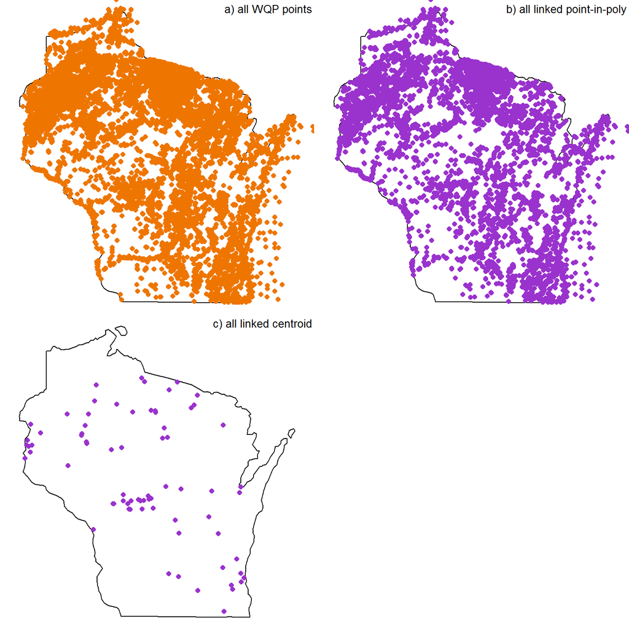

```r
wi = USAboundaries::us_boundaries()[USAboundaries::us_boundaries()$geoid %in% c('55'),]
all_points = st_as_sf(lsites, coords = c("LongitudeMeasure", "LatitudeMeasure"), crs = '+proj=longlat +ellps=WGS84 +datum=WGS84 +no_defs')

par(mfrow=c(2,2), mar=c(0,0,0,0))
plot(st_geometry(wi))
plot(st_geometry(all_points), col='darkorange2', add=TRUE, pch=16)
legend('topright', legend=' ', title='a) all WQP points', bty='n')

pippoints = subset(all_points, MonitoringLocationIdentifier %in% linked_lakes$MATCH_ID)
plot(st_geometry(wi))
plot(st_geometry(pippoints), col='darkorchid3', add=TRUE, pch=16)
legend('topright', legend=' ', title='b) all linked point-in-poly', bty='n')

centpoints = subset(all_points, MonitoringLocationIdentifier %in% linked_lcent$MATCH_ID)
plot(st_geometry(wi))
plot(st_geometry(centpoints), col='darkorchid3', add=TRUE, pch=16)
legend('topright', legend=' ', title='c) all linked centroid', bty='n')


# gall = ggplot(all_points) +
#   geom_sf(data=wi, fill='grey') +
#   geom_sf(size=0.5, color='darkorange2') + ylim(42, 47) + xlim(-93, -86.5) +
#   ggtitle('a) all WQP points')
#
# glink = ggplot(subset(all_points, MonitoringLocationIdentifier %in% linked_lakes$MATCH_ID)) +
#   geom_sf(data=wi, fill='grey') +
#   geom_sf(size=0.5, color='dodgerblue') + ylim(42, 47) + xlim(-93, -86.5) +
#   ggtitle('b) all linked point-in-poly')
#
# gcent = ggplot(subset(all_points, MonitoringLocationIdentifier %in% linked_lcent$MATCH_ID)) +
#   geom_sf(data=wi, fill='grey') +
#   geom_sf(size=0.5, color='darkorchid3') + ylim(42, 47) + xlim(-93, -86.5) +
#   ggtitle('c) all linked centroid')
#
#
# grid.arrange(gall, glink, gcent, nrow = 2)
```